# Econ144_hw5

4. Based on your findings from Exercise 3, calculate the one and two‐step ahead volatility forecasts. Construct a 95% interval forecast for the SP500 returns. Assume that the returns are conditionally normal distributed.

```r
# one- step ahead volatility of garch
z <- rnorm(1) # random number follow normal distribution
sigma_last <- var(g_vol$fitted.values[,1], na.rm=TRUE)
sigma <- sqrt(g_vol$coef[1] + g_vol$coef[2]*(g_vol$residuals[3355])^2 + g_vol$coef[3]*sigma_last)
gf_step1 <- g_vol$fitted.values[,1][3355] + sigma*z
print("After calculating, one step forecast of garch(1,1) is ")
```

```
## [1] "After calculating, one step forecast of garch(1,1) is "
```

```r
print(gf_step1)
```

```
##       a0
## 2829.135
```

```r
z2 <- rnorm(1) # random number follow normal distribution
f1_data <- c(g_vol$fitted.values[,1], gf_step1)
sigma_f1 <- var(f1_data, na.rm=TRUE)
sigma_2 <- sqrt(g_vol$coef[1] + (g_vol$coef[2] + g_vol$coef[3])*sigma_f1)
gf_step2 <- gf_step1 + sigma_2*z2
print("After calculating, two step forecast of garch(1,1) is ")
```

```
## [1] "After calculating, two step forecast of garch(1,1) is "
```

```r
print(gf_step2)
```

```
##       a0
## 1965.103
```

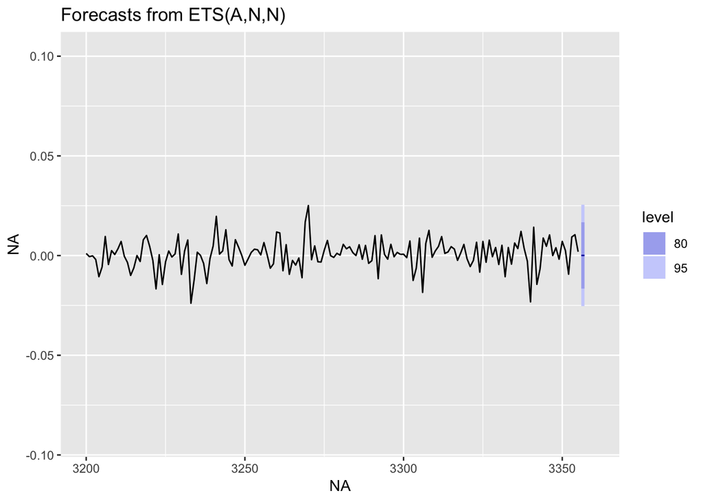

```r
# try to forecast return for 20 steps ahead
return_forecast <- forecast(unlist(sp500_lrtrn), h = 2)
autoplot(return_forecast) +
  xlim(3200, 3360) # set the window to have a better observation on the forecast
```

5. In Exercise 5 of Chapter 13, you downloaded the time series of US CPI and GDP and constructed the inflation rate and GDP growth. For each, calculate the unconditional mean, and compute the 1‐step‐ahead volatility forecast by implementing the best (G)ARCH model, and construct the corresponding 95% interval forecast.

```r
setwd("/Users/Renaissance/Desktop")
# read cpi and gdp data
cpi <- read_xls("hw5_14a.xls", sheet = 2)
```

```
## * `` -> ...3
```

```r
gdp <- read_xls("hw5_14a.xls", sheet = 3)
```

```
## * `` -> ...3
```

```r
cpi <- cpi[,c(1,2)]
gdp <- gdp[,c(1,2)]  #eliminate nan

cpi_ts <- ts(cpi[,2],start = c(1947,1), end = c(2013,3), frequency = 12)
gdp_ts <- ts(gdp[,2],start = c(1947,1), end = c(2013,3), frequency = 12)

# inflation
cpi_value <- unlist(cpi[,2])
inflation <- (cpi_value - Lag(cpi_value, 1))/ Lag(cpi_value, 1)
# GDP growth
gdp_value <- unlist(gdp[,2])
growth <- (gdp_value - Lag(gdp_value, 1))/ Lag(gdp_value, 1)

# calculate the unconditional mean
print("The unconditional mean of cpi is ")
```

```
## [1] "The unconditional mean of cpi is "
```

```r
print(mean(cpi[,2]))
```

```
## [1] NA
```

```r
print("The unconditional mean of gdp is ")
```

```
## [1] "The unconditional mean of gdp is "
```

```r
print(mean(gdp[,2]))
```

```
## [1] NA
```

```r
# fit garch
inflation_nonan <- na.omit(inflation)
g_inflation <- garch(x = inflation_nonan, order = c(1, 1))
```

[output not shown]

```r
summary(g_inflation)
```

```
##
## Call:
## garch(x = inflation_nonan, order = c(1, 1))
##
## Model:
## GARCH(1,1)
##
## Residuals:
##     Min      1Q  Median      3Q     Max
## -3.4465  0.3451  0.7437  1.1383  3.8784
##
## Coefficient(s):
##     Estimate  Std. Error  t value Pr(>|t|)
## a0 9.492e-07   2.568e-07    3.696 0.000219 ***
## a1 2.312e-01   3.293e-02    7.021 2.21e-12 ***
## b1 7.008e-01   3.385e-02   20.704  < 2e-16 ***
## ---
## Signif. codes:  0 '***' 0.001 '**' 0.01 '*' 0.05 '.' 0.1 ' ' 1
##
## Diagnostic Tests:
##  Jarque Bera Test
##
## data:  Residuals
## X-squared = 368.51, df = 2, p-value < 2.2e-16
##
##
##  Box-Ljung test
##
## data:  Squared.Residuals
## X-squared = 0.019688, df = 1, p-value = 0.8884
```

```r
paste("In this cast, garch(1,1) gives the best fit")
```

```
## [1] "In this cast, garch(1,1) gives the best fit"
```

```r
# one step ahead forecast
z_cpi <- rnorm(1) # random number follow normal distribution
sigma_last_cpi <- var(g_inflation$fitted.values[,1], na.rm=TRUE)
sigma_cpi <- sqrt(g_inflation$coef[1] + g_inflation$coef[2]*(g_inflation$residuals[794])^2 + g_inflation$coef[3]*sigma_last_cpi)
gf_step1_cpi <- g_inflation$fitted.values[,1][794] + sigma_cpi*z
print("After calculating, one step forecast of garch(1,1) is ")
```

```
## [1] "After calculating, one step forecast of garch(1,1) is "
```

```r
print(as.numeric(gf_step1_cpi))
```

```
## [1] 0.6333554
```

```r
print("The 95% interval of this one step ahead forecast is between :")
```

```
## [1] "The 95% interval of this one step ahead forecast is between :"
```

```r
print(as.numeric(gf_step1_cpi - 1.96*sigma_cpi))
```

```
## [1] 0.2039261
```

```r
print(" and ")
```

```
## [1] " and "
```

```r
print(as.numeric(gf_step1_cpi +1.96*sigma_cpi))
```

```
## [1] 1.062785
```

6. Given this expression, retrieve the residuals and construct the 1‐step‐ahead volatility forecast by implementing the best (G)ARCH model. Construct the corresponding 95% interval forecast for inflation and GDP growth, and compare these intervals with those from Exercise 5.

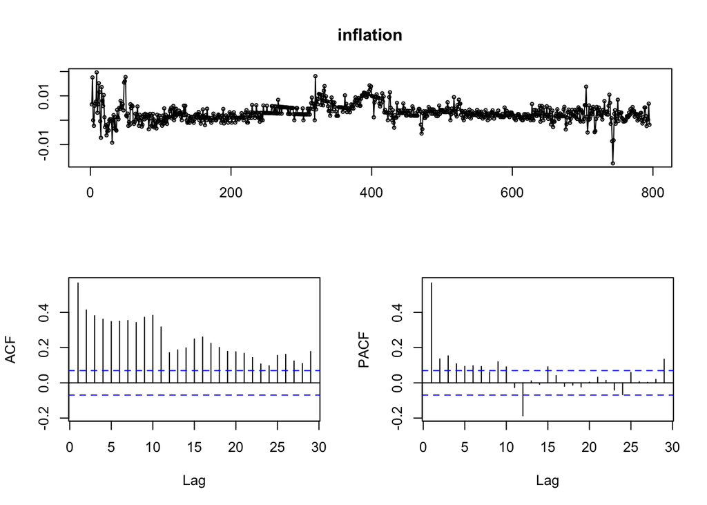

```r
tsdisplay(inflation) # view the inflation rate (from cpi)
```

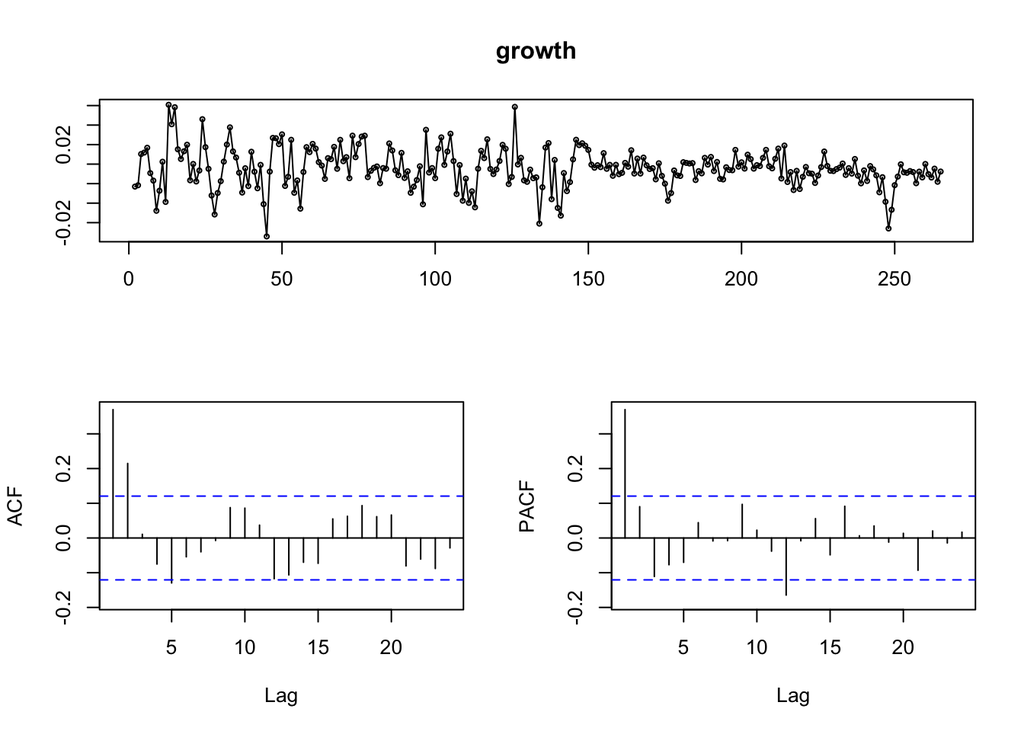

```r
arimafit <- auto.arima(inflation)
inflation_resi <- arimafit$residuals# retrieve the residual

tsdisplay(growth) # view the growth rate (from gdp)
```

```r
arimafit_growth <- auto.arima(gdp_ts)
growth_resi <- arimafit_growth$residuals# retrieve the residual

# garch fit of inflation residual
g_ir<- garch(x = inflation_resi, order = c(1, 1))
```

[output not shown]

```r
summary(g_ir)   # garch (1, 1) gives the best fit
```

```
##
## Call:
## garch(x = inflation_resi, order = c(1, 1))
##
## Model:
## GARCH(1,1)
##
## Residuals:
##      Min       1Q   Median       3Q      Max
## -4.65799 -0.58537 -0.03286  0.57848  4.64900
##
## Coefficient(s):
##     Estimate  Std. Error  t value Pr(>|t|)
## a0 3.592e-07   6.447e-08    5.572 2.52e-08 ***
## a1 1.948e-01   2.056e-02    9.473  < 2e-16 ***
## b1 7.635e-01   2.058e-02   37.093  < 2e-16 ***
## ---
## Signif. codes:  0 '***' 0.001 '**' 0.01 '*' 0.05 '.' 0.1 ' ' 1
##
## Diagnostic Tests:
##  Jarque Bera Test
##
## data:  Residuals
## X-squared = 156.55, df = 2, p-value < 2.2e-16
##
##
##  Box-Ljung test
##
## data:  Squared.Residuals
## X-squared = 0.93926, df = 1, p-value = 0.3325
```

```r
# garch fit of gdp growth residual
g_gr<- garch(x = growth_resi, order = c(0, 1))
```

[output not shown]

[output cut: 44 more lines]

```r
summary(g_gr)  # arch (0, 1) gives the best fit
```

```
##
## Call:
## garch(x = growth_resi, order = c(0, 1))
##
## Model:
## GARCH(0,1)
##
## Residuals:
##       Min        1Q    Median        3Q       Max
## -20.29706   0.02525   0.07557   0.13216   0.36462
##
## Coefficient(s):
##     Estimate  Std. Error  t value Pr(>|t|)
## a0 3.483e+05   1.198e+03    290.9   <2e-16 ***
## a1 3.436e-09   3.433e-03      0.0        1
## ---
## Signif. codes:  0 '***' 0.001 '**' 0.01 '*' 0.05 '.' 0.1 ' ' 1
##
## Diagnostic Tests:
##  Jarque Bera Test
##
## data:  Residuals
## X-squared = 4948700, df = 2, p-value < 2.2e-16
##
##
##  Box-Ljung test
##
## data:  Squared.Residuals
## X-squared = 0.0051985, df = 1, p-value = 0.9425
```

```r
# one-step ahead forecast of garch in inflation residual
z_in <- rnorm(1) # random number follow normal distribution
sigma_last_in <- var(g_ir$fitted.values[,1], na.rm=TRUE) # last sigma
sigma_in <- sqrt(g_ir$coef[1] + g_ir$coef[2]*(g_ir$residuals[794])^2 + g_ir$coef[3]*sigma_last_in) # sigma at this time
gf_step1_in <- g_ir$fitted.values[,1][794] + sigma_in*z_in # forecast 1 step
print("After calculating, one step forecast of garch(1,1) of inflation residual is ")
```

```
## [1] "After calculating, one step forecast of garch(1,1) of inflation residual is "
```

```r
print(as.numeric(gf_step1_in))
```

```
## [1] -0.1947071
```

```r
print("The 95% interval of this one step ahead forecast is between :")
```

```
## [1] "The 95% interval of this one step ahead forecast is between :"
```

```r
print(as.numeric(gf_step1_in - 1.96*sigma_in))
```

```
## [1] -1.618182
```

```r
print(" and ")
```

```
## [1] " and "
```

```r
print(as.numeric(gf_step1_in +1.96*sigma_in))
```

```
## [1] 1.228768
```

```r
# one-step ahead forecast of arch in growth rate reisudal
z_gr <- rnorm(1)
meanfit_gr <- mean(g_gr$fitted.values[,1], na.rm = TRUE)
sigma_last_gr <- (g_gr$fitted.values[,1][794] - meanfit_gr)^2 # last sigma
sigma_gr <- sqrt(g_gr$coef[1] + g_gr$coef[2]*sigma_last_gr) # sigma at this time
gf_step1_gr <- g_gr$fitted.values[,1][794] + sigma_gr*z_gr  # forecast 1 step
print("After calculating, one step forecast of garch(1,1) of growthrate residual is ")
```

[output not shown]

```r
print(as.numeric(gf_step1_gr))
```

```
## [1] 694.3022
```

```r
print("The 95% interval of this one step ahead forecast is between :")
```

```
## [1] "The 95% interval of this one step ahead forecast is between :"
```

```r
print(as.numeric(gf_step1_gr - 1.96*sigma_gr))
```

```
## [1] -462.4971
```

```r
print(" and ")
```

```
## [1] " and "
```

```r
print(as.numeric(gf_step1_gr +1.96*sigma_gr))
```

```
## [1] 1851.101
```